# QTM 151 - Intro to Statistical Programming II

Lecture 13 - Replacing and Recoding Variables

Danilo Freire

danilo.freire@emory.edu

Emory University

# Nice to see you again! How was your break? 🍂

# Today’s plan 📅

## Creating and replacing variables

### Today we will…

- Learn how to recode and replace variables in a dataset
- Specifically focus on replacing `NaN` values (“Not a Number” - missing data)
- Cover how to convert variables from one type to another
- Learn how to create new variables based on existing ones
- We will use our friends `pandas` and `numpy` to do this 🐼

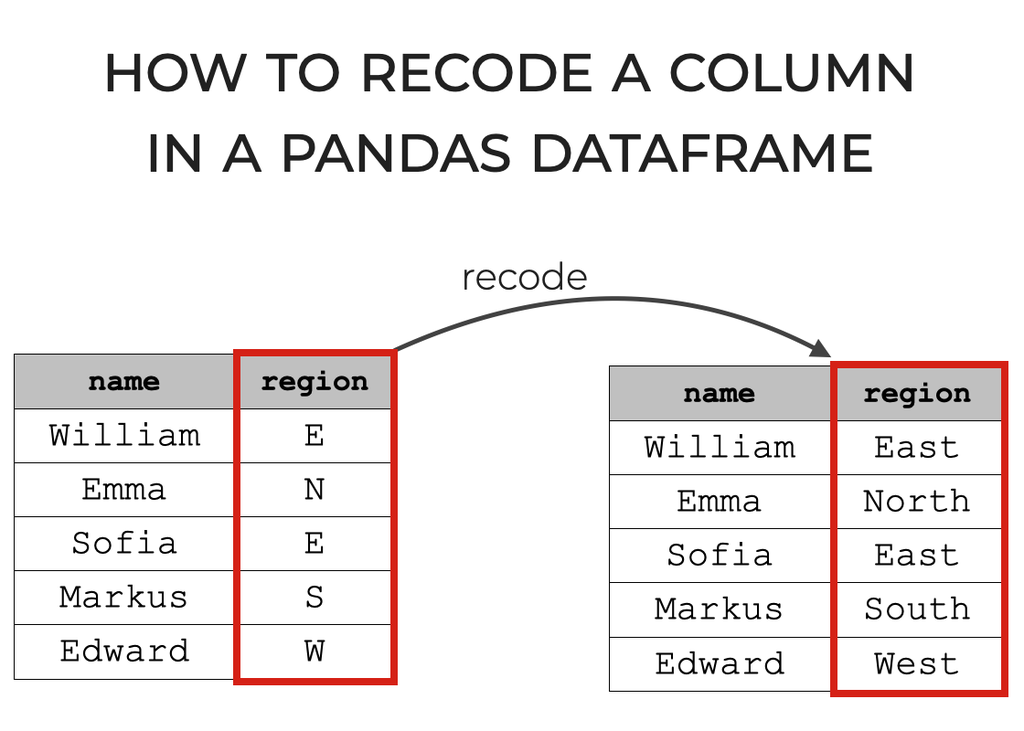

# Loading packages and dataset 📦

## Our dataset: Formula 1 World Championships 🏁🏎️

- First, we will load the packages we need

```python
import pandas as pd
import numpy as np
```

- Then, we will load the dataset

```python
circuits = pd.read_csv("https://github.com/danilofreire/qtm151/raw/refs/heads/main/lectures/lecture-13/data_raw/circuits.csv")

# Or open it from the local file
# circuits = pd.read_csv("data_raw/circuits.csv")

display(circuits.head(2))
```

|  | circuitId | circuitRef | name | location | country | lat | lng | alt | url |
| --- | --- | --- | --- | --- | --- | --- | --- | --- | --- |
| 0 | 1 | albert_park | Albert Park Grand Prix Circuit | Melbourne | Australia | -37.84970 | 144.968 | 10 | http://en.wikipedia.org/wiki/Melbourne_Grand_P... |
| 1 | 2 | sepang | Sepang International Circuit | Kuala Lumpur | Malaysia | 2.76083 | 101.738 | 18 | http://en.wikipedia.org/wiki/Sepang_Internatio... |

- The dataset contains information about F1 circuits, such as its name, location, latitude, longitude, and more
- You can find more information about the dataset [here](https://www.kaggle.com/datasets/rohanrao/formula-1-world-championship-1950-2020/data)
- The dataset is available in the course’s GitHub repository [here](https://github.com/danilofreire/qtm151/blob/main/lectures/lecture-13/data_raw/circuits.csv)
  - Or you can download it using the command above
- Let’s see how the codebook looks like
- More information about [Formula 1 here](https://en.wikipedia.org/wiki/Formula_One)

## Codebook 📚

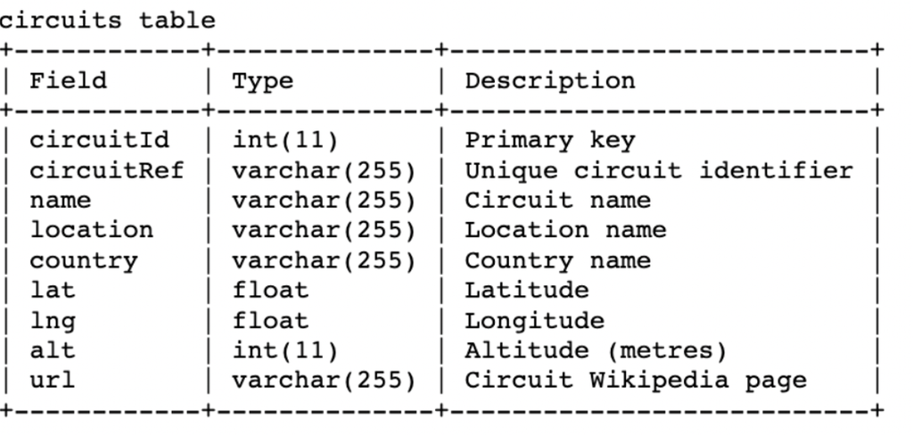

- `Field` - Name of the variable
- `Type` - Type of the variable
  - Integer (`int`), string (`str` - `varchart`), and float (`float`)
- `Description` - Label with a description of the variable
- Quick discussion: What does `varchart(255)` mean?
- The dataset has 9 columns (variables) and 77 rows (observations)
- The columns are:
  - `circuitId`: Unique identifier for the circuit
  - `circuitRef`: Unique reference for the circuit
  - `name`: Name of the circuit
  - `location`: Location
  - `country`: Country where the circuit is located
  - `lat`: Latitude
  - `lng`: Longitude
  - `alt`: Altitude
  - `url`: URL of the circuit’s Wikipedia page

# NaN values 🚫

## What is a `NaN` value?

- `NaN` stands for “Not a Number”
- It is a special value in Python that represents missing data
- `NaN` values can be found in datasets for various reasons
  - Data entry errors
  - Data cleaning and processing errors
  - Data collection errors
  - Data transformation errors
- We (often) need to handle `NaN` values before we can analyse the data
- `NaN` values can be found in different types of variables
  - Numeric variables
  - Categorical variables
  - Date variables
  - Text variables
- We will focus on numeric variables today
- `pandas` and `numpy` have functions to handle `NaN` values
  - Note: they handle `NaN` values differently!

## Operations with `NaN` values

- `NaN` is a special number, available in `numpy`

```python
np.nan
```

```
nan
```

- Often, we cannot perform operations with `NaN` values
- Thus, we need to handle them before we can analyse the data
- Let’s see some examples. We start with `numpy` arrays

```python
# Create two array with and without "NaNs"
# The "np.array()" functions converts
# a list to an array

vec_without_nans = np.array([1,1,1])
vec_with_nans    = np.array([np.nan,4,5])

# When you add the vectors
# you will produce a NaN
# on any entries with "NaNs"
print(vec_without_nans * vec_with_nans)
print(vec_without_nans / vec_with_nans)
print(vec_without_nans + vec_with_nans)
print(vec_without_nans - vec_with_nans)
```

```
[nan  4.  5.]
[ nan 0.25 0.2 ]
[nan  5.  6.]
[nan -3. -4.]
```

## Summary statistics with `NaN` values

### Arrays

- Some summary statistics functions will not work with `NaN` values
- For example, the `mean()` function

```python
print(np.mean(vec_with_nans))
```

```
nan
```

- The `mean()` function will return `NaN` if there are `NaN` values in the array
- To calculate the mean without `NaN` values, we can use the `nanmean()` function

```python
print(np.nanmean(vec_with_nans))
```

```
4.5
```

- The `nanmean()` function will ignore `NaN` values and calculate the mean with the remaining values

## Summary statistics with `NaN` values

### Pandas DataFrames

- Let’s create an empty DataFrame and create a new column `x` with `NaN` values

```python
dataset = pd.DataFrame()
dataset["x"] = vec_with_nans
dataset
```

|  | x |
| --- | --- |
| 0 | NaN |
| 1 | 4.0 |
| 2 | 5.0 |

- You will see that `pandas` will handle `NaN` values differently: it will ignore them

```python
print(dataset["x"].mean())
```

```
4.5
```

- For R users: This is the same as `na.rm = TRUE` in R. `pandas` does that by default

# Data Cleaning 🧹🧽

## Data cleaning

- Data cleaning is the process of preparing data for analysis
- It involves identifying and handling missing data, outliers, and other data quality issues
- You guys have no idea how much time you will spend cleaning data in your life 😅
- According to a [Forbes survey](https://www.forbes.com/sites/gilpress/2016/03/23/data-preparation-most-time-consuming-least-enjoyable-data-science-task-survey-says/), data scientists spend 60% of their time cleaning and preparing data, and 57% say it’s the least enjoyable part of their work
  - I can really relate to that 😂
- But remember that clean data are good data 🥳
- Let’s get the data types of the columns in the `circuits` dataset
- We use the command `dtypes` for that
- `object` means that the variable is a string or a variable with mixed types (e.g., numbers and strings)

```python
circuits.dtypes
```

```
circuitId       int64
circuitRef     object
name           object
location       object
country        object
lat           float64
lng           float64
alt            object
url            object
dtype: object
```

## Check rows with numeric values

- Here we will use the `.str.isnumeric()` function
- This function actually combines two functions: `.str` and `.isnumeric()`
- The `.str` function is used to check if the variable is a string
- The `.isnumeric()` part is used to check if the string is numeric
- Why do we need both? Because DataFrame columns often contain mixed data types (e.g., numbers and strings), and we need to check if the variable is a string before we can check if it is numeric
- If we used only `.isnumeric()`, we would get an error (trust me, I tried 😅)
- The two dots between the functions are called method chaining
- It is a way to call multiple functions in a single line of code
- If you use `R`, this is similar to the `%>%` operator in `dplyr`
- Let’s see how it works

```python
# Check if the variable "alt" is numeric
circuits["alt"].str.isnumeric()
```

```
0      True
1      True
2      True
3      True
4      True
      ...
72     True
73     True
74     True
75    False
76    False
Name: alt, Length: 77, dtype: bool
```

## Other examples of chaining methods

```python
# Check if the variable "circuitRef" is numeric
circuits["circuitRef"].str.isnumeric()
```

```
0     False
1     False
2     False
3     False
4     False
      ...
72    False
73    False
74    False
75    False
76    False
Name: circuitRef, Length: 77, dtype: bool
```

```python
# Convert the variable `location` to lowercase
circuits["location"].str.lower()
```

```
0        melbourne
1     kuala lumpur
2           sakhir
3         montmeló
4         istanbul
          ...
72        portimão
73         mugello
74          jeddah
75       al daayen
76           miami
Name: location, Length: 77, dtype: object
```

## Extract list of non-numeric values

- Remember `.query()`? We can use it to reference subattributes of a variable
- Here we will combine it with `pd.unique()` to extract a list of non-numeric values
- The `pd.unique()` function will return a list of unique values in a variable

```python
# Extract a list of non-numeric values
# The pd.unique() function extracts unique values from a list
# Check each value in the alt column to see if it is not numeric
# True if it is not numeric, False if it is numeric
subset = circuits.query("alt.str.isnumeric() == False")
list_unique = pd.unique(subset["alt"])
print(list_unique)
```

```
['\\N' '-7']
```

## Replace certain values

- The `replace` function is used to replace values in a variable
- The syntax is `dataframe["variable"].replace(list_old, list_new)`
- More information about the function can be found [here](https://pandas.pydata.org/pandas-docs/stable/reference/api/pandas.DataFrame.replace.html)

```python
# "list_old" encodes values we want to change
# From the list_unique, we see that the values we want to change are '\N' and '-7'
# "list_new" encodes the values that will replace the old
list_old = ['\\N','-7']
list_new = [np.nan, -7]

# This command replaces the values of the "alt" column
circuits["alt"] = circuits["alt"].replace(list_old, list_new)
```

- After the cleaning process is done, you may want to store the dataset again
- It’s strongly recommended to do this in a separate file from the original
- Use `to_csv()` to save the dataset as a `.csv` file

```python
circuits.to_csv("data_clean/circuits_clean.csv", index=False)
```

## Try it yourself! 🧠

- Use `.replace()` with the “country” column
- Replace “UK” with “United Kingdom”
- Appendix 01

## Try it yourself! 🧠

- What is the column type of “lat” or “lng”?
- Does it have any string variables?
- Can we use `str.isnumeric()` here?

# Recoding Numeric Variables 🔄

## Recoding numeric variables

- Recoding is the process of changing the values of a variable
- We can recode variables for various reasons
  - To create new variables
  - To standardise variables
  - To simplify the analysis
- Please remember to convert the variable to the correct type before recoding

```python
# Check the data type of the "alt" column
circuits["alt"].dtype
```

```
dtype('O')
```

- `pd.to_numeric()` is used to convert a variable to a numeric type

```python
# pd.to_numeric() converts
# a column to numeric
# Before you use this option,
# make sure to "clean" the variable
# as we did before by checking what
# the non-numeric values are
circuits["alt_numeric"] = pd.to_numeric(circuits["alt"])
print(circuits["alt_numeric"].mean())
```

```
248.1891891891892
```

```python
print(circuits["alt_numeric"].min())
print(circuits["alt_numeric"].max())
```

```
-7.0
2227.0
```

## Recode variables based on an interval

- Imagine that we want to recode the `alt` variable into an interval

$$x_{bin} = \begin{cases} "A" &\text{ if } x_1 < x \le x_2 \\
"B" &\text{ if } x_2 < x \le x_3 \end{cases}$$

- We can use the `pd.cut()` function to do this
- The syntax is `df["new_variable"] = pd.cut(df["variable"], bins = [x1, x2, x3], labels = ["A", "B"])`
- Where `bins` are the intervals and `labels` are the new values
- More information about the function can be found [here](https://pandas.pydata.org/pandas-docs/stable/reference/api/pandas.cut.html)

```python
# Recode the "alt" variable into an interval
bins_x = [0, 2500, 5000]
labels_x = ["Between 0 and 2500",
            "Between 2500 and 5000"]

circuits["bins_alt"] = pd.cut(circuits["alt_numeric"],
                              bins = bins_x,
                              right = True,
                              labels = labels_x)
np.random.seed(2014)
display(circuits.sample(5))
```

|  | circuitId | circuitRef | name | location | country | lat | lng | alt | url | alt_numeric | bins_alt |
| --- | --- | --- | --- | --- | --- | --- | --- | --- | --- | --- | --- |
| 75 | 78 | losail | Losail International Circuit | Al Daayen | Qatar | 25.4900 | 51.45420 | NaN | http://en.wikipedia.org/wiki/Losail_Internatio... | NaN | NaN |
| 52 | 53 | essarts | Rouen-Les-Essarts | Rouen | France | 49.3306 | 1.00458 | 81 | http://en.wikipedia.org/wiki/Rouen-Les-Essarts | 81.0 | Between 0 and 2500 |
| 36 | 37 | detroit | Detroit Street Circuit | Detroit | USA | 42.3298 | -83.04010 | 177 | http://en.wikipedia.org/wiki/Detroit_street_ci... | 177.0 | Between 0 and 2500 |
| 76 | 79 | miami | Miami International Autodrome | Miami | USA | 25.9581 | -80.23890 | NaN | http://en.wikipedia.org/wiki/Miami_Internation... | NaN | NaN |
| 70 | 71 | sochi | Sochi Autodrom | Sochi | Russia | 43.4057 | 39.95780 | 2 | http://en.wikipedia.org/wiki/Sochi_Autodrom | 2.0 | Between 0 and 2500 |

## Try it yourself! 🧠

- Create a new variable “hemisphere”
- Encode lattitude in (-90 and 0] as “south”
- Encode lattitude in (0 and 90] as “north”
- Appendix 03

# And that’s it for today! 🎉

# See you next time! 🚀

## Appendix 01

```python
# Replace "UK" with "United Kingdom"
circuits["country"] = circuits["country"].replace("UK", "United Kingdom")

# Check the rows where the replacement was made
uk = circuits.query("country == 'United Kingdom'")
display(uk.head(5))
```

|  | circuitId | circuitRef | name | location | country | lat | lng | alt | url | alt_numeric | bins_alt |
| --- | --- | --- | --- | --- | --- | --- | --- | --- | --- | --- | --- |
| 8 | 9 | silverstone | Silverstone Circuit | Silverstone | United Kingdom | 52.0786 | -1.016940 | 153 | http://en.wikipedia.org/wiki/Silverstone_Circuit | 153.0 | Between 0 and 2500 |
| 30 | 31 | donington | Donington Park | Castle Donington | United Kingdom | 52.8306 | -1.375280 | 88 | http://en.wikipedia.org/wiki/Donington_Park | 88.0 | Between 0 and 2500 |
| 37 | 38 | brands_hatch | Brands Hatch | Kent | United Kingdom | 51.3569 | 0.263056 | 145 | http://en.wikipedia.org/wiki/Brands_Hatch | 145.0 | Between 0 and 2500 |
| 57 | 58 | aintree | Aintree | Liverpool | United Kingdom | 53.4769 | -2.940560 | 20 | http://en.wikipedia.org/wiki/Aintree_Motor_Rac... | 20.0 | Between 0 and 2500 |

Back to exercise

## Appendix 02

```python
# Check the data type of the "lat" column
print(circuits["lat"].dtype)
```

```
float64
```

```python
# Check if the "lat" column has any string values
# print(circuits["lat"].str.isnumeric())
# No, it gives an error!

# This one doesn't work either
# print(circuits.query("lat.str.isnumeric() == False"))

# We can use the following command to check if the column has any string values
print(circuits["lat"].dtype == 'string')
```

```
False
```

Back to exercise

## Appendix 03

```python
# Create a new variable "hemisphere"
# Encode lattitude in (-90 and 0] as "south"
# Encode lattitude in (0 and 90] as "north"
bins_lat = [-90, 0, 90]
labels_lat = ["south", "north"]

circuits["hemisphere"] = pd.cut(circuits["lat"],
                                bins = bins_lat,
                                right = True,
                                labels = labels_lat)
np.random.seed(151)
display(circuits.sample(5))
```

|  | circuitId | circuitRef | name | location | country | lat | lng | alt | url | alt_numeric | bins_alt | hemisphere |
| --- | --- | --- | --- | --- | --- | --- | --- | --- | --- | --- | --- | --- |
| 22 | 80 | vegas | Las Vegas Strip Street Circuit | Las Vegas | United States | 36.11470 | -115.17300 | NaN | https://en.wikipedia.org/wiki/Las_Vegas_Grand_... | NaN | NaN | north |
| 61 | 62 | monsanto | Monsanto Park Circuit | Lisbon | Portugal | 38.71970 | -9.20306 | 158 | http://en.wikipedia.org/wiki/Monsanto_Park_Cir... | 158.0 | Between 0 and 2500 | north |
| 7 | 8 | magny_cours | Circuit de Nevers Magny-Cours | Magny Cours | France | 46.86420 | 3.16361 | 228 | http://en.wikipedia.org/wiki/Circuit_de_Nevers... | 228.0 | Between 0 and 2500 | north |
| 1 | 2 | sepang | Sepang International Circuit | Kuala Lumpur | Malaysia | 2.76083 | 101.73800 | 18 | http://en.wikipedia.org/wiki/Sepang_Internatio... | 18.0 | Between 0 and 2500 | north |
| 28 | 29 | adelaide | Adelaide Street Circuit | Adelaide | Australia | -34.92720 | 138.61700 | 58 | http://en.wikipedia.org/wiki/Adelaide_Street_C... | 58.0 | Between 0 and 2500 | south |

Back to exercise

[Variables](https://raw.githack.com/danilofreire/qtm151/main/lectures/lecture-13/13-replacing-recoding-variables.html)